# randomForestVIP Vignette

Kelvyn Bladen

2023-07-18

## Overview

The goal of `randomForestVIP` is to tune and select a Random Forest model with high accuracy and interpretability. This is done by tuning the Random Forest based on the accuracy and variable importance metrics associated with each model. To accomplish this, functions are available to tabulate and plot results designed to help the user select an optimal model.

The function `mtry_compare` may be used to tune the hyper-parameter mtry based on model performance and variable importance metrics. This grid-search technique provides tables and plots showing the effect of mtry on each of the assessment metrics. It also returns each of the evaluated models to the user.

This package also contains functions for assessing relationships among the predictor variables and between the predictors and response. These are relevant for any predictive model, not just Random Forests. Metrics such as partial correlations and variance inflation factors are available for a variety of modeling techniques (not just linear regressions). These are tabulated and plotted for the analyst using the functions `partial_cor` and `robust_vifs`.

The package also provides superior `ggplot2` variable importance plots for individual models using the function `ggvip`. This function is a highly aesthetic and editable improvement upon the function `randomForest::varImpPlot` and other basic importance graphics.

All of the plots generated by these functions are developed with `ggplot2` techniques so that the user has the ability to edit and improve further upon the plots.

For methodology see “Contributions to Random Forest Variable Importance with Applications in R” https://digitalcommons.usu.edu/etd/8587/.

## Example: Boston

```r
library(randomForestVIP)
library(MASS)
library(EZtune)
```

To introduce the functionality of `randomForestVIP`, we look at modeling the Boston housing data (found in the MASS package). We want to build a Random Forest model with a view towards both accuracy and interpretability. We begin by running some preliminary diagnostics on our data.

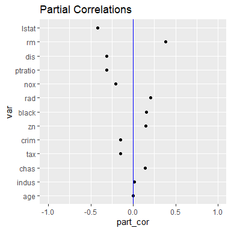

```r
set.seed(1234)

pcs <- partial_cor(medv ~ ., data = Boston, model = lm)
pcs$plot_y_part_cors
```

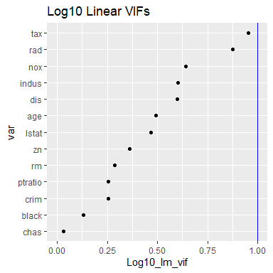

```r
rv <- robust_vifs(medv ~ ., data = Boston, model = lm)
rv$plot_lin_vifs
```

These functions assess concerns with collinearity. Notice that the VIFs from `robust_vifs` are all less than 10. The partial correlations with the response from `partial_cor` are a type of pseudo-importance assessing the importance each variable does not share with the others. Now we tune our model by assessing four different mtry values in the `mtry_compare` function.

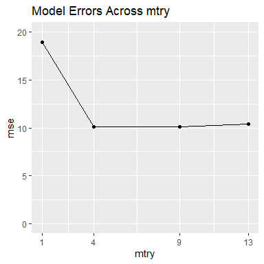

```r
set.seed(1)
m <- mtry_compare(medv ~ .,
  data = Boston, sqrt = TRUE,
  mvec = c(1, 4, 9, 13), num_var = 7
)
m$gg_model_errors
```

```r
m$model_errors
```

```
#>   mtry      mse
#> 1    1 18.96051
#> 2    4 10.11247
#> 3    9 10.13187
#> 4   13 10.36482
```

According to the accuracy plot and table above, our best choice is when mtry is 4. However, the accuracy for the best model is notably only slightly better than the models with mtry set to 9 and 13. We now look at the variable importance metrics across the different models.

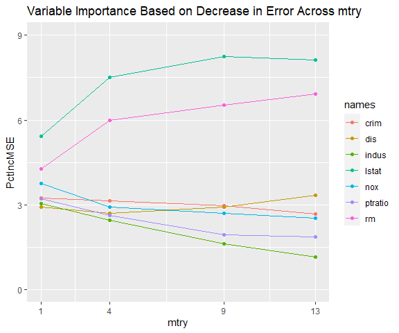

```r
m$gg_var_imp_error
```

The top two variables are consistently identified as more important than the other variables and their order remains unchanged across mtry. However, the variables ‘nox’ and ‘dis’ switch order as mtry increases. Pollution (nox) has a strong negative correlation with distance to employment centers (dis). This makes sense if the employment centers are responsible for much of the pollution. If many home buyers consider distance to work more important than pollution when selecting a house, ‘dis’ is more likely to be a causal driver of price than ‘nox’. By this reasoning, the model where mtry is 9 appears to be superior to the model where mtry is 4, despite mtry of 4 yielding slightly more accurate results.

We now take our selected model and build individual importance plots for it using `ggvip`.

```r
g <- ggvip(m$rf9)$both_vips
```

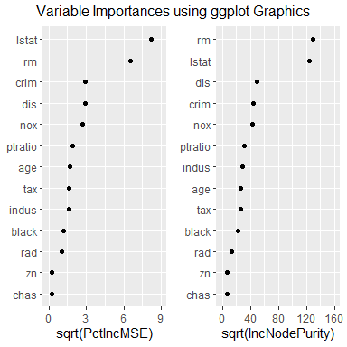

The plot above resembles a standard variable importance plot, but possesses superior tick labels and editing capabilities for the analyst.

We have used the `randomForestVIP` package to tune a strong model for prediction and with reasonably useful importance values. This was accomplished by assessing variable importance and accuracy metrics across the hyper-parameter mtry.

## Example: Lichens in Pacific Northwest

```r
library(randomForestVIP)
```

To further demonstrate the functionality of `randomForestVIP`, we provide another example. This time using classification data. We look at modeling the Lichen data (found in the EZtune package) with a view towards both accuracy and interpretability. The response is presence or absence (coded 0 or 1) of a lichen species, Lobaria oregana. We begin by running preliminary diagnostics on our data using `partial_cor` and `robust_vifs`.

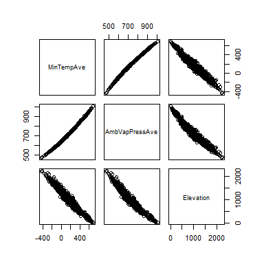

```r
set.seed(1234)

lichen <- EZtune::lichen[, -c(1, 3:8)]

pairs(lichen[, c(16, 20, 26)])
```

```r
cor(lichen[, c(16, 20, 26)])
```

```
#>                MinTempAve AmbVapPressAve  Elevation
#> MinTempAve      1.0000000      0.9973158 -0.9781953
#> AmbVapPressAve  0.9973158      1.0000000 -0.9745659
#> Elevation      -0.9781953     -0.9745659  1.0000000
```

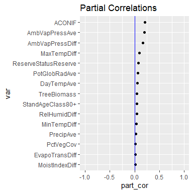

```r
pcs <- partial_cor(factor(LobaOreg) ~ .,
  data = lichen, model = lm,
  num_var = 15
)
pcs$plot_y_part_cors
```

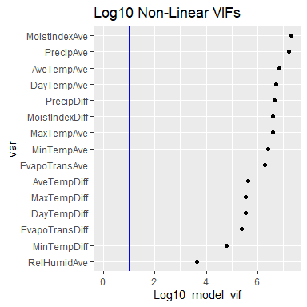

```r
rv <- robust_vifs(factor(LobaOreg) ~ .,
  data = lichen, model = lm,
  num_var = 15
)
rv$plot_nonlin_vifs
```

These variables exhibit high collinearity. To illustrate this observation, consider the pairs plots above for ‘MinTempAve’, ‘Elevation’, and ‘AmbVapPressAve’. Most of the VIFs from `robust_vifs` exceed the standard threshold. The partial correlations with the response from `partial_cor` are a type of pseudo-importance assessing the importance each variable does not share with the others. Now we tune our Random Forest model across four mtry values.

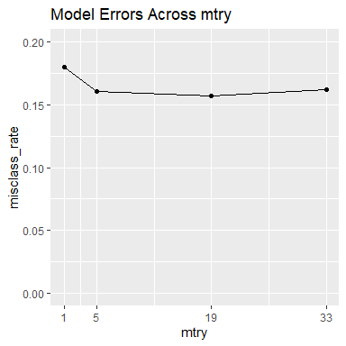

```r
set.seed(100)
m <- mtry_compare(factor(LobaOreg) ~ .,
  data = lichen, sqrt = TRUE,
  mvec = c(1, 5, 19, 33), num_var = 7
)
m$gg_model_errors
```

```r
m$model_errors
```

```
#>   mtry misclass_rate
#> 1    1     0.1797619
#> 2    5     0.1607143
#> 3   19     0.1571429
#> 4   33     0.1619048
```

According to the accuracy plot and table above, our best choice is when mtry is 19. However, the accuracy for the best model is only slightly better than the models with mtry set to 5 and 33. We now look at the variable importance metrics across the different models.

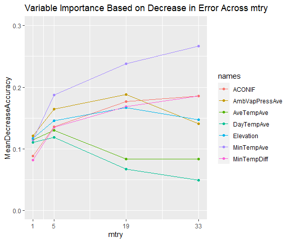

```r
m$gg_var_imp_error
```

There are 3 variables to focus on. ‘MinTempAve’, ‘Elevation’, and ‘AmbVapPressAve’ were all shown to be highly correlated above. These variables appear to be the most importance variable when mtry is small. However, as mtry increases, the importance of ‘Elevation’ drops off a bit, and the importance of ‘AmbVapPressAve’ drops even more. After seeing these changes, a researcher might consider how these variables actually affect lichen presence. They would find that ‘MinTempAve’ informs freezing which directly contributes to lichen presence. They would also realize that ‘Elevation’ indirectly causes lichen presence since ‘Elevation’ drives ‘MinTempAve’. ‘AmbVapPressAve’ can be assumed to be a byproduct of ‘Elevation’ and is not a feature that should have much of a causal impact on lichen presences. While it is highly predictive, it is not something a scientist would prescribe for inducing the response. In this example, as mtry increases, casual variables rise while collinear byproducts fall.

No solution is perfect, but mtry of 33 yields results that match the intuition about the effect our predictors have on the response.

We now take our selected model and build individual importance plots for it using `ggvip`.

```r
g <- ggvip(m$rf33, num_var = 12)$both_vips
```

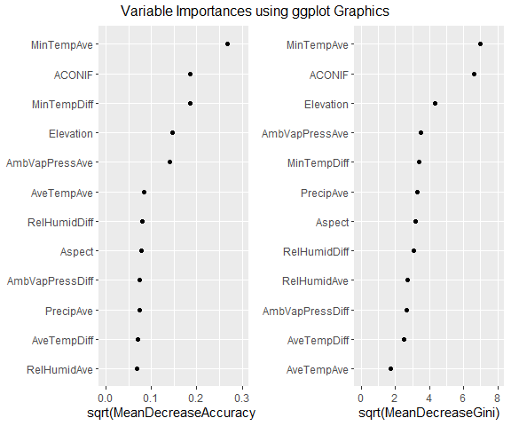

We have used the `randomForestVIP` package to tune a model for prediction and with superior importance values. This was accomplished by assessing variable importance and accuracy metrics across the hyper-parameter mtry.